# Reference Proteomes Taxonomical Analysis

Kilicali Isildayancan

19 March 2023

# Taxonomical Analysis

## High-level taxonomy (Superkingdoms, kingdoms, and phylum)

### Superkingdoms

- There are 1 superkingdom(s), namely: Eukaryota. Eukaryotes represent 100 (There are 0 from Bacteria).

### Kingdoms

- There are 3 kingdoms, namely: Viridiplantae, Fungi, Metazoa. Here is the distribution:

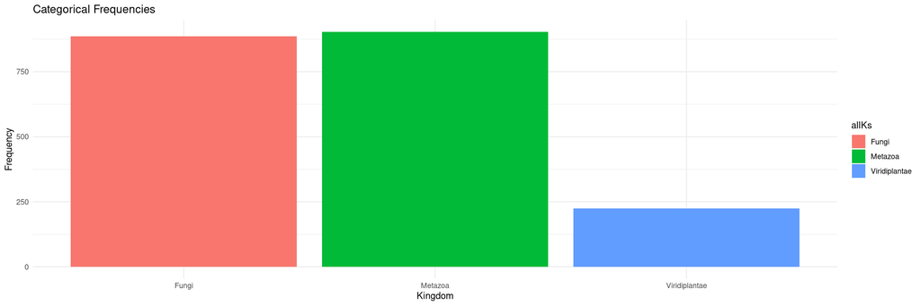

### Phylum

- There are 42 phylums, namely: Streptophyta, Ascomycota, Arthropoda, Chordata, Euglenozoa, Basidiomycota, Ciliophora, Bacillariophyta, Microsporidia, Chlorophyta, Evosea, Apicomplexa, Parabasalia, Fornicata, Cnidaria, Nematoda, Oomycota, Mollusca, Heterolobosea, Rhodophyta, Echinodermata, Chytridiomycota, Perkinsozoa, Porifera, Platyhelminthes, Placozoa, Mucoromycota, Discosea, Haptophyta, Annelida, Foraminifera, Cryptomycota, Endomyxa, Blastocladiomycota, Zoopagomycota, Orthonectida, Brachiopoda, Tardigrada, Rotifera, Cercozoa, Bryozoa, Olpidiomycota.

Here is a visual representation of all the phylums present (which covers all the lower-level taxa):

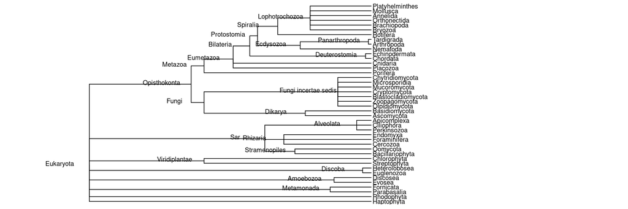

Also the histogram distribution:

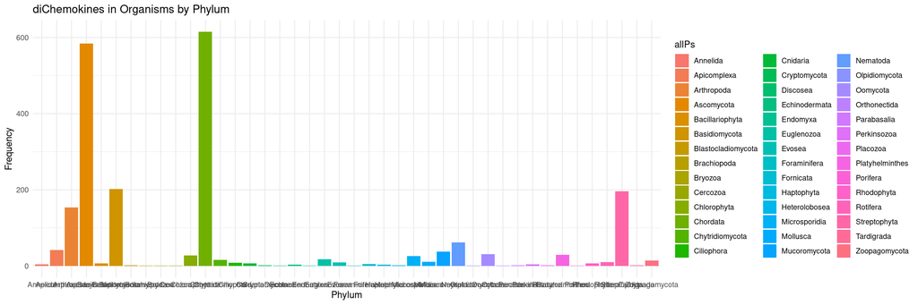

The chordates represent 28.551532 of all the phylums in the reference proteomes with a total of 615.

## Mid-level taxonomy (Order)

We are considering only order here, and looking for primates in particular.

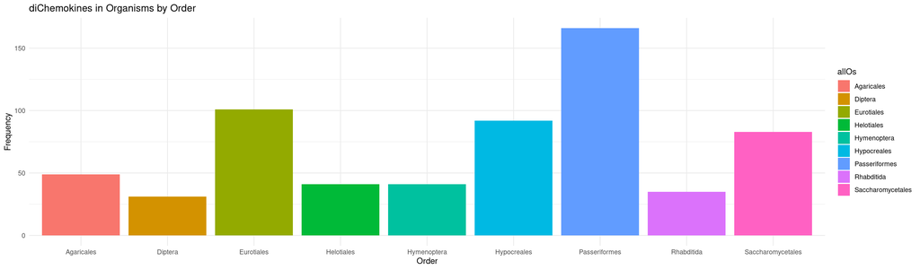

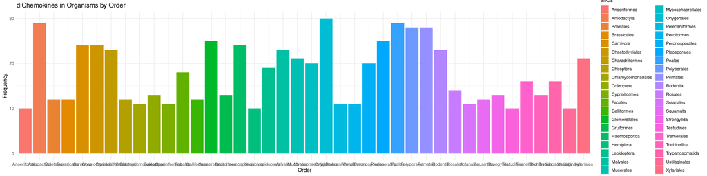

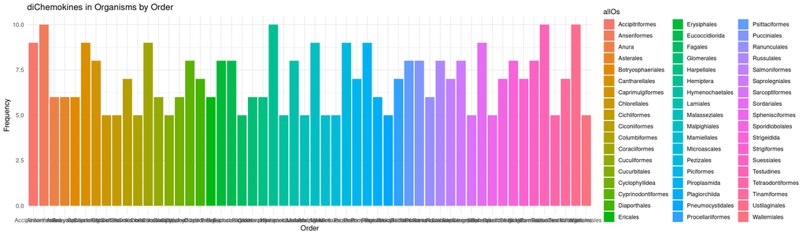